# ggplot2 package

Jindra

11/21/2017

## ggplot2 plotting library

The qplot() function actually creates a ggplot object rather than directly plotting. When such objects are printed, the effect of printing is that they are plotted. That sounds a bit confusing, but it is what happens.

```r
library(ggplot2)
library(magrittr)
data(cars)
#qplot stands for quick plot
cars %>% qplot(speed, dist, data = .)
```

[output not shown]

```r
#or
#cars %$% qplot(speed, dist, data = .)
```

The previous code is equivalent to this:

```r
p <- cars %>% qplot(speed, dist, data = .)
p
#or also
p <- cars %>% qplot(speed, dist, data = .)
print(p)
```

[output not shown]

### iris dataset usecase

the visualization of data points depend on data variables in a simpler way than you can with plot()

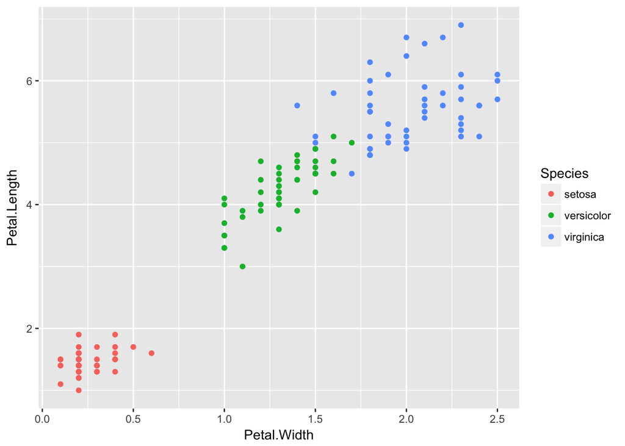

```r
iris %>% qplot(Petal.Width, Petal.Length, data = ., color = Species)
```

### Histograms, Density plots

When only x parameter is specified, histogram is created

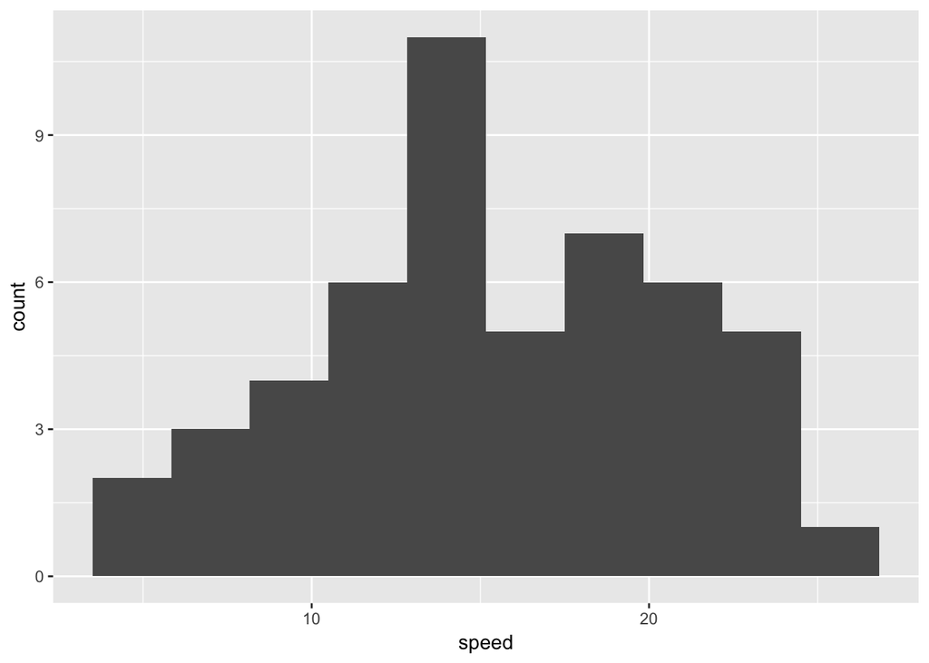

```r
cars %>% qplot(speed, data = ., bins = 10)
```

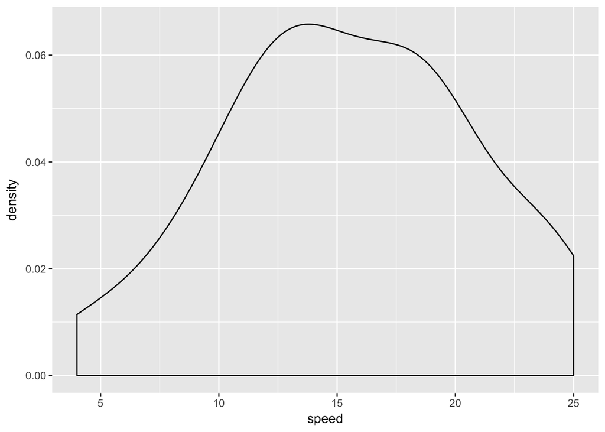

```r
cars %>% qplot(speed, data = ., geom="density")
```

### Create plots with geometries instead of qplot

To create this plot using explicit geometries we want a ggplot object, we need to map the speed parameter from the data frame to the x-axis and the dist parameter to the y-axis, and we need to plot the data as points. We create an object using the ggplot() function. We give it the cars data as input. When we give this object the data frame, following operations can access the data. We specify that we want the x- and y-values to be plotted as points by calling geom_point() and we map speed to the x-values and dist to the y-values using the “aesthetics” function aes(). You use + to string together a series of commands to modify a ggplot object in a way very similar to how we use %>% to string together a sequence of data manipulations. (The only reason that these are two different operators here are historical)

```r
ggplot(cars) + geom_point(aes(x = speed, y = dist))
```

[output not shown]

```r
#aes can be defined "globally"
#ggplot(cars, aes(x = speed, y = dist)) + geom_point()
```

### Typical uses of ggplot object when combined with data manipulation

```r
cars %>% ggplot(aes(x = speed, y = dist)) + geom_point()
```

[output not shown]

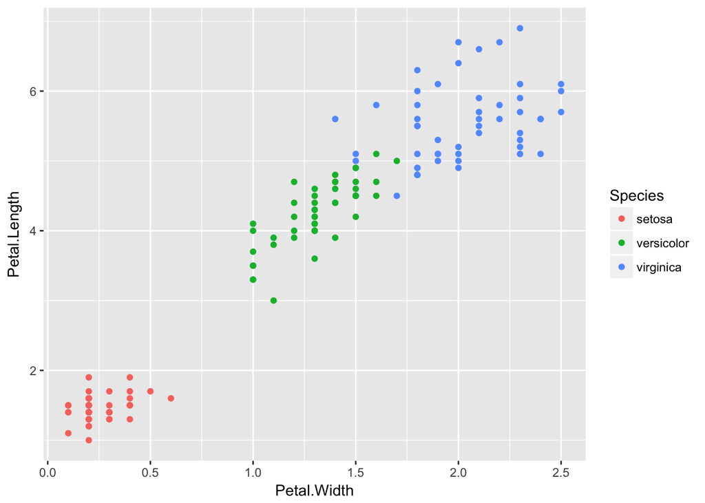

```r
#iris %>% qplot(Petal.Width, Petal.Length, data = ., color = Species)
iris %>% ggplot(aes(x = Petal.Width, y = Petal.Length, color = Species)) +
  geom_point()
```

```r
#iris %>% ggplot(aes(x = Petal.Width, y = Petal.Length, color = "red")) +
#  geom_point() #hardwired red color for all points
```

For Histogram and Density

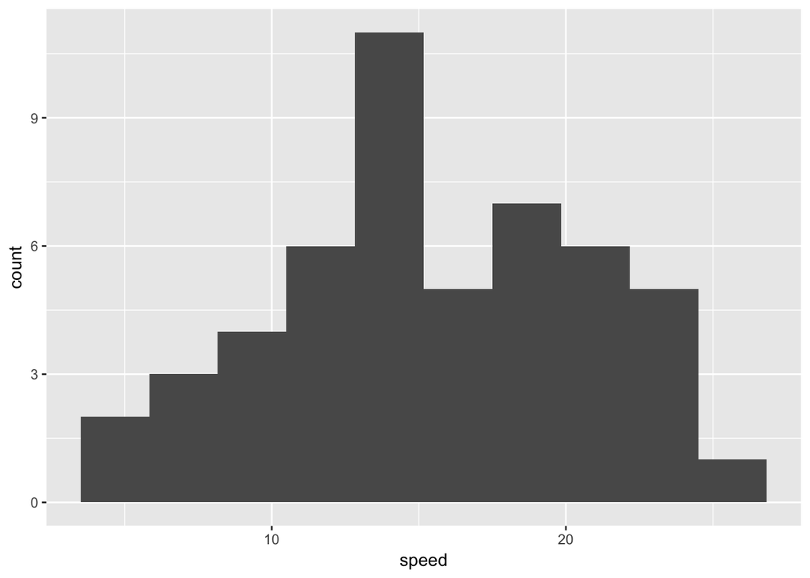

```r
ggplot(cars) + geom_histogram(aes(x = speed), bins = 10)
```

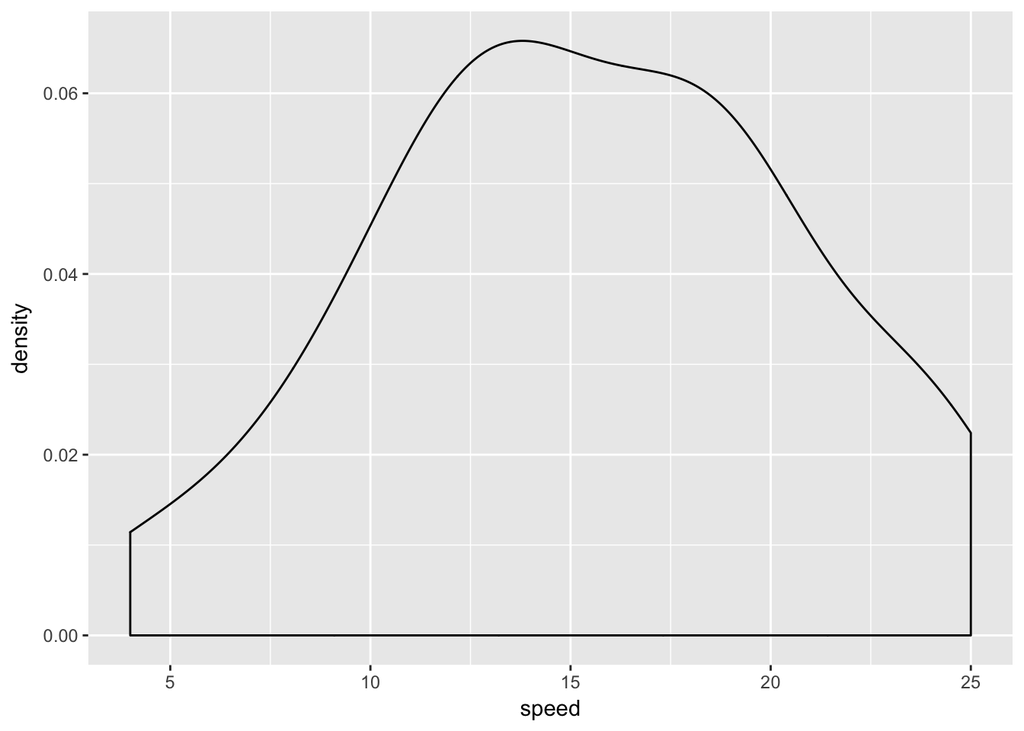

```r
ggplot(cars) + geom_density(aes(x = speed))
```

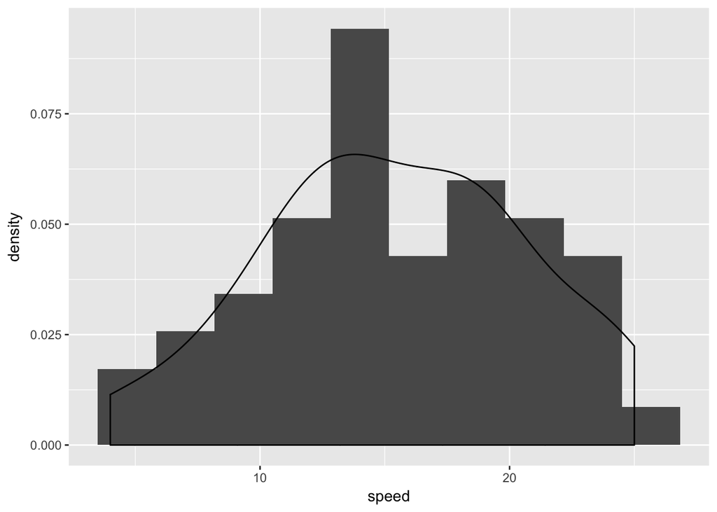

```r
#It can be used to create multilayer plots
#try also y = ..cpunt..
cars %>% ggplot(aes(x = speed, y = ..density..)) +
  geom_histogram(bins = 10) +
  geom_density()
```

### Linear fit

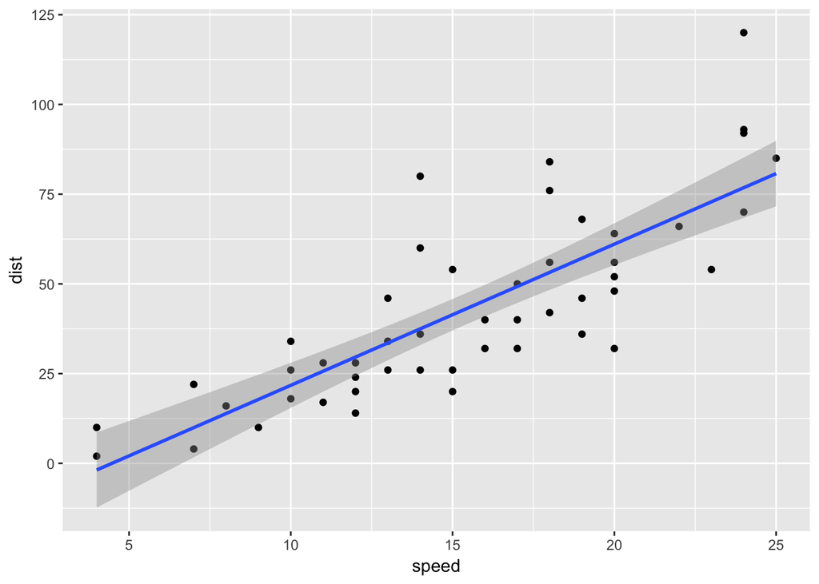

```r
cars %>% ggplot(aes(x = speed, y = dist)) + geom_point() + geom_smooth(method = "lm")
```

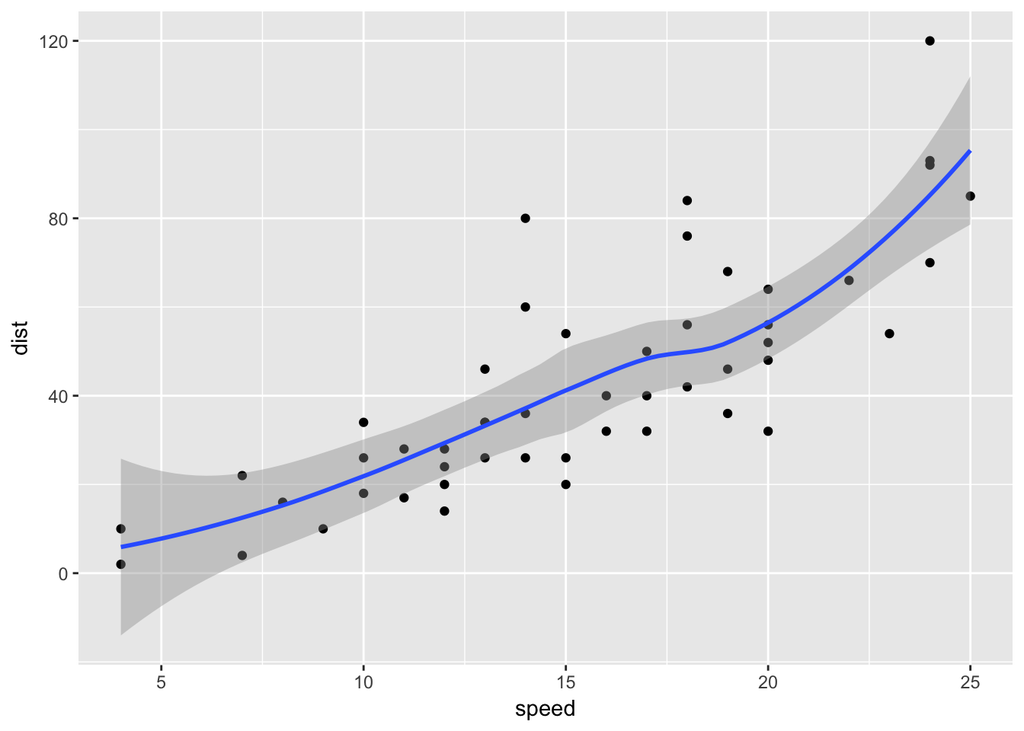

```r
#non=linear is default (method = "loess")
cars %>% ggplot(aes(x = speed, y = dist)) + geom_point() + geom_smooth()
```

### More than one datasets

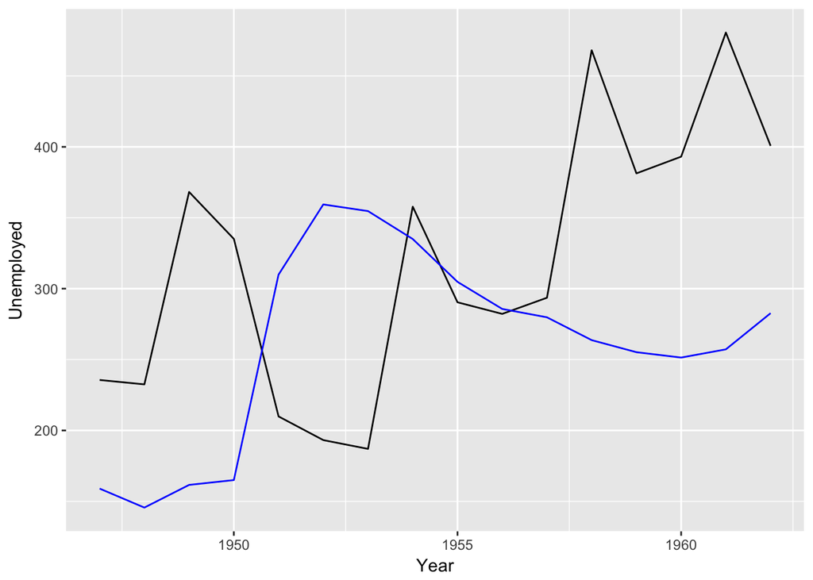

```r
data("longley")
longley %>% ggplot(aes(x = Year)) +
  geom_line(aes(y = Unemployed)) +
  geom_line(aes(y = Armed.Forces), col = "blue")
```

### Combine lines and points

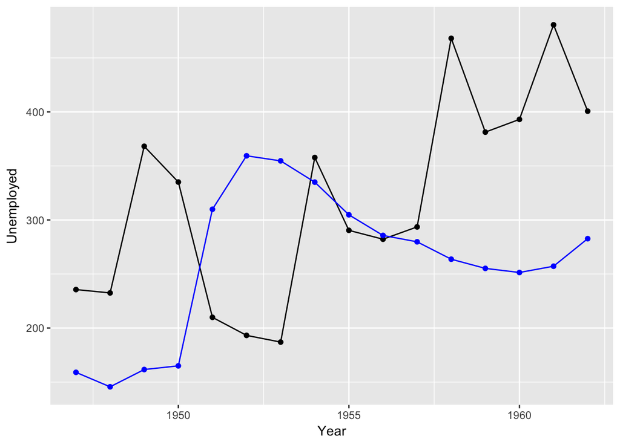

```r
longley %>% ggplot(aes(x = Year)) +
  geom_line(aes(y = Unemployed)) +
  geom_line(aes(y = Armed.Forces), col = "blue") +
  geom_point(aes(y = Unemployed)) +
  geom_point(aes(y = Armed.Forces), col = "blue")
```

### Use tidyr to prepare data for better analysis and subplotting

```r
library(tidyr)
```

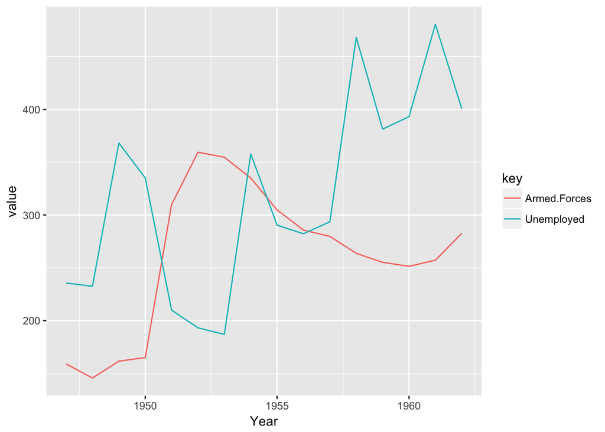

```r
longley %>% gather(key, value, Unemployed, Armed.Forces) %>%
  ggplot(aes(x = Year, y = value, color = key)) + geom_line()
```

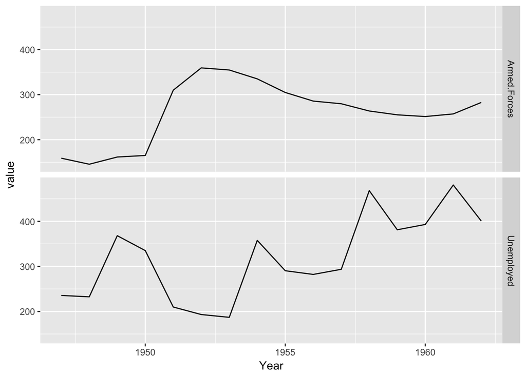

```r
#sublots (facets)
longley %>% gather(key, value, Unemployed, Armed.Forces) %>%
  ggplot(aes(x = Year, y = value)) + geom_line() +
  facet_grid(key ~ .)
```

Facets are created by 2 functions facet_grid() and facet_wrap() facet_grid() creates a row for the variables on the left side of the formula and a column for the variables on the right side and builds facets based on this: “key ∼ .”, so we get a row per key “. ∼ key” instead, we would get a column per key facet_wrap() doesn’t explicitly set up rows and columns, it simply makes a facet per combination of variables on the right side of the formula and wraps the facets in a grid to display them

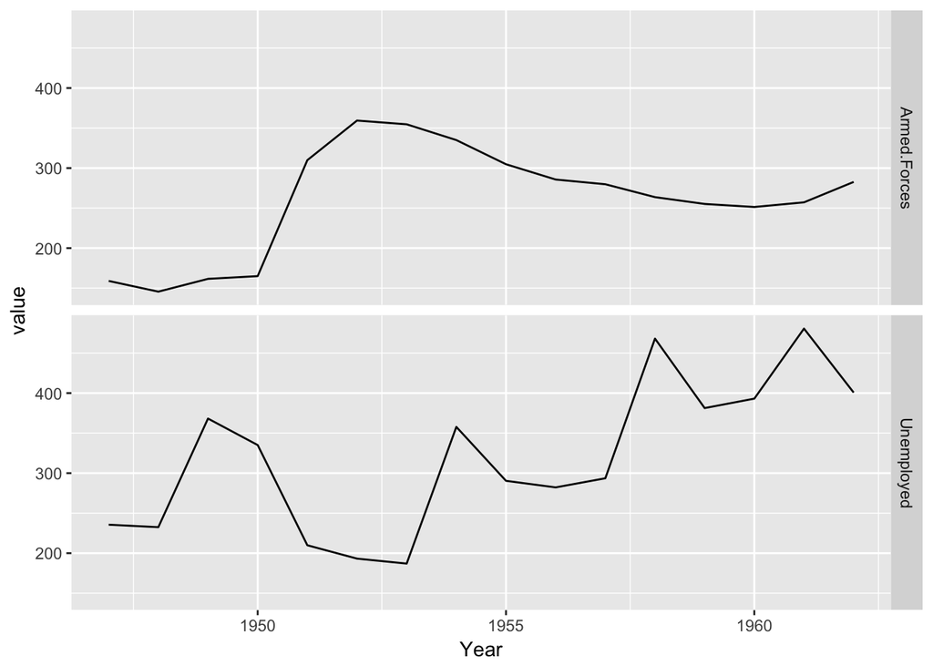

```r
longley %>% gather(key, value, Unemployed, Armed.Forces) %>%
  ggplot(aes(x = Year, y = value)) + geom_line() +
  facet_grid(key ~ .)
```

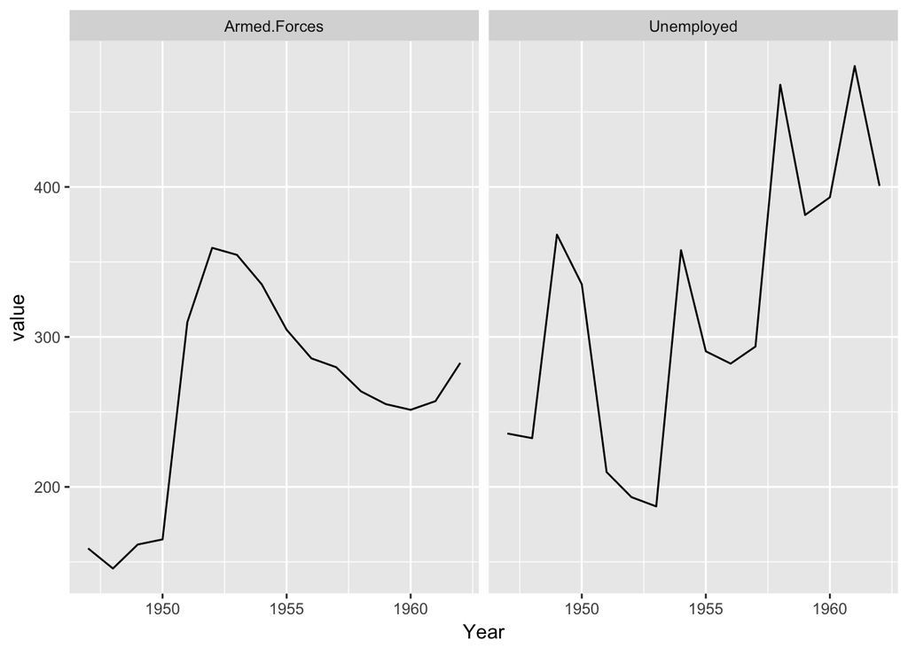

```r
longley %>% gather(key, value, Unemployed, Armed.Forces) %>%
  ggplot(aes(x = Year, y = value)) + geom_line() +
  facet_grid(. ~ key)
```

When the dataset needs to be splitted into facets, gather function is possibly used

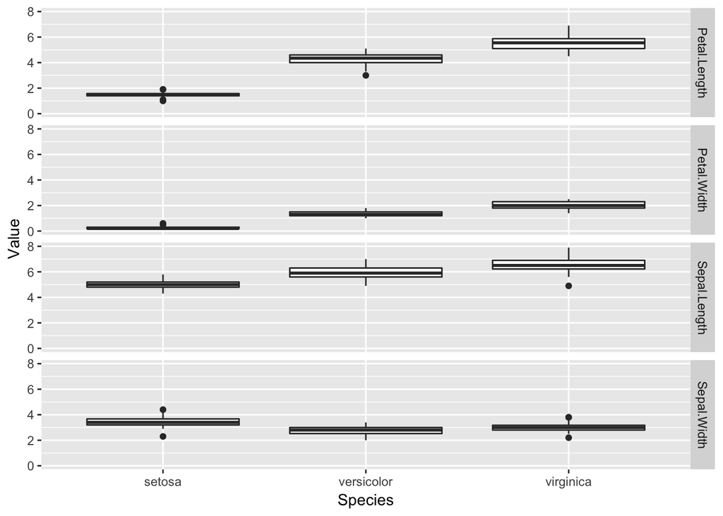

```r
iris %>% gather(Measurement, Value, -Species) %>%
  ggplot(aes(x = Species, y = Value)) + geom_boxplot() +
  facet_grid(Measurement ~ .)
```

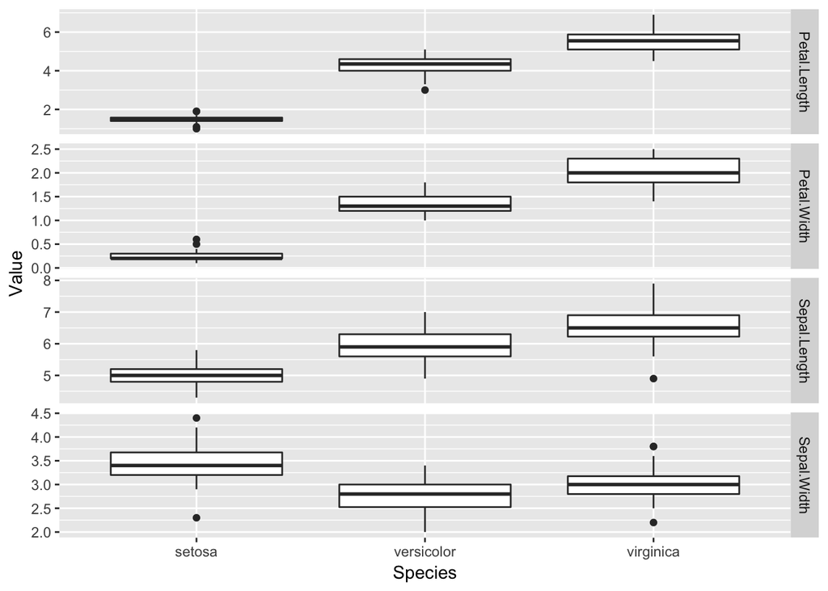

```r
iris %>% gather(Measurement, Value, -Species) %>%
  ggplot(aes(x = Species, y = Value)) +  geom_boxplot() +
  facet_grid(Measurement ~ ., scale = "free_y")
```

### Change the label names

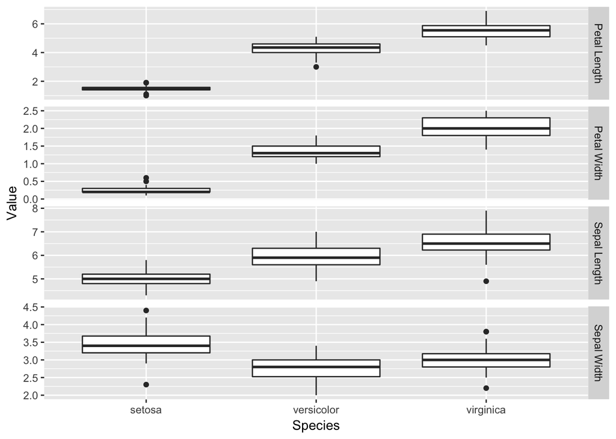

```r
label_map <- c(Petal.Width = "Petal Width",
               Petal.Length = "Petal Length",
               Sepal.Width = "Sepal Width",
               Sepal.Length = "Sepal Length")

iris %>% gather(Measurement, Value, -Species) %>%
  ggplot(aes(x = Species, y = Value)) +
  geom_boxplot() +
  facet_grid(Measurement ~ ., scale = "free_y",
             labeller = labeller(Measurement = label_map))
```

### Scales

Put labels on the axes, manipulate the ticks, reverse axes

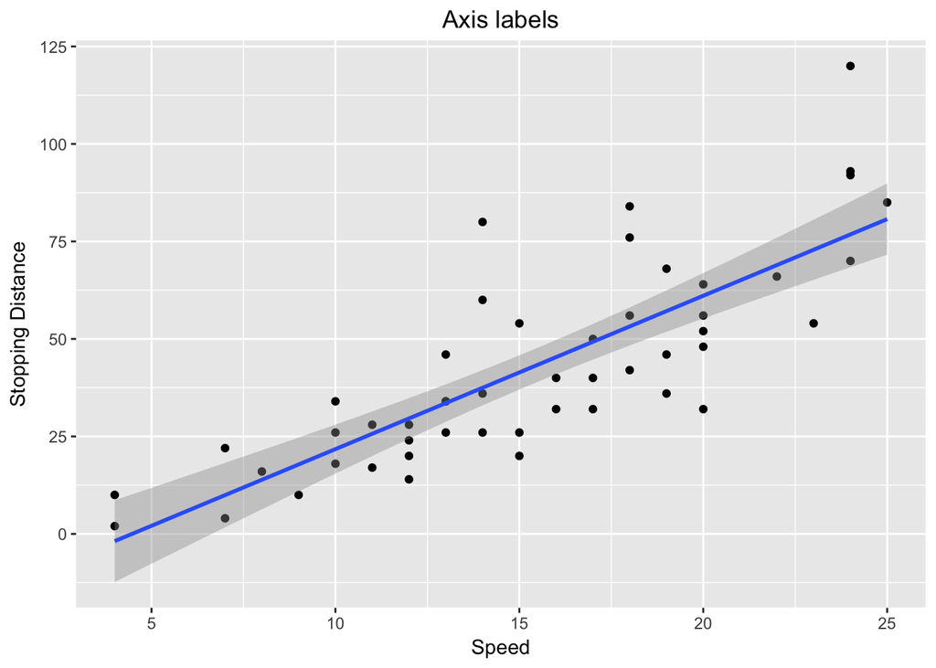

```r
#labels
cars %>% ggplot(aes(x = speed, y= dist)) + geom_point() +
  ggtitle("Axis labels") +
  theme(plot.title = element_text(hjust = 0.5)) + #center the label
  geom_smooth(method = "lm") +
  scale_x_continuous("Speed") +
  scale_y_continuous("Stopping Distance")
```

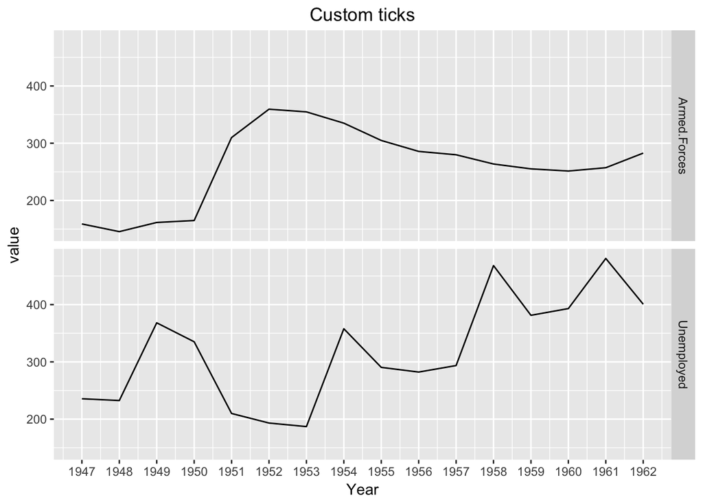

```r
data("longley")
#ticks
longley %>% gather(key, value, Unemployed, Armed.Forces) %>%
  ggplot(aes(x = Year, y = value)) +
  ggtitle("Custom ticks") +
  theme(plot.title = element_text(hjust = 0.5)) + #center the label
  geom_line() +
  scale_x_continuous(breaks = 1947:1962) +
  facet_grid(key ~ .)
```

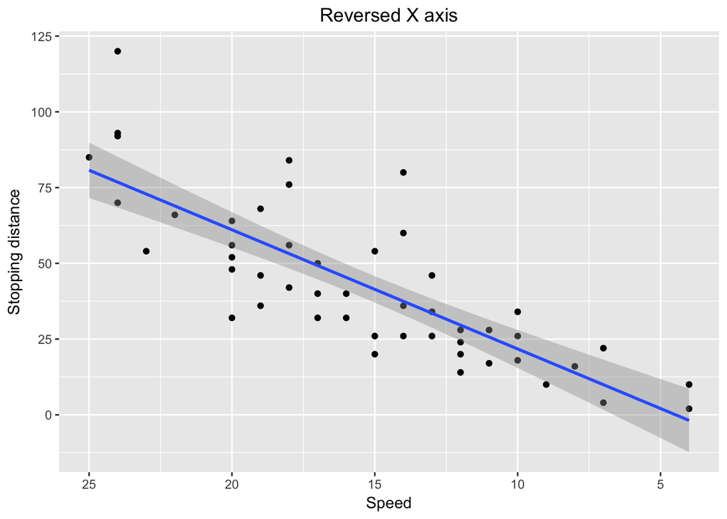

```r
#reverse and plot title
cars %>% ggplot(aes(x = speed, y = dist)) +
  ggtitle("Reversed X axis") +
  theme(plot.title = element_text(hjust = 0.5)) + #center the label
  geom_point() +
  geom_smooth(method = "lm") +
  scale_x_reverse("Speed") +
  scale_y_continuous("Stopping distance")
```

### Factors on x-axis (discrete) and geom_jitter

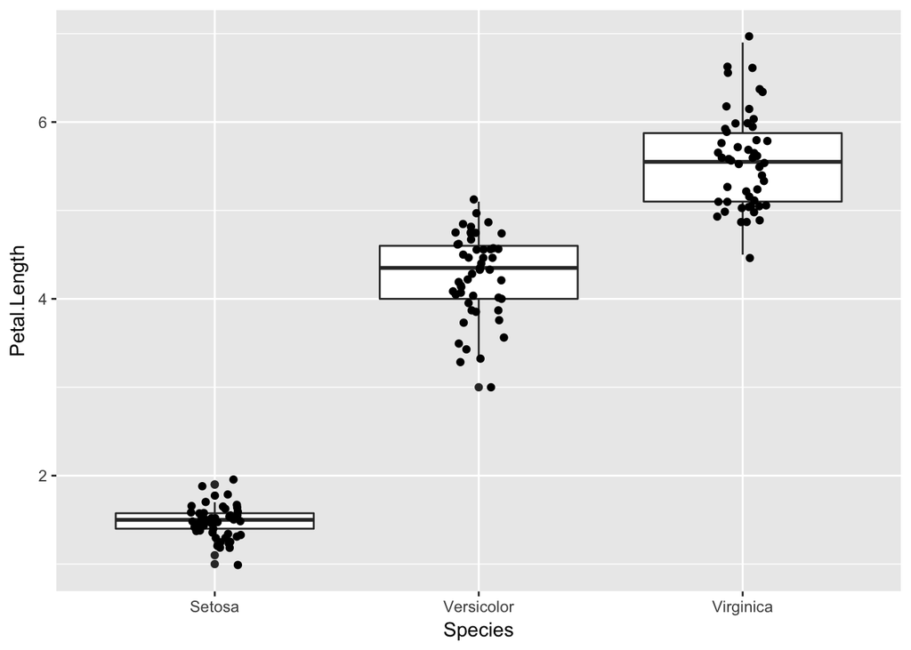

```r
iris %>% ggplot(aes(x = Species, y = Petal.Length)) +
  geom_boxplot() +
  geom_jitter(width = 0.1, height = 0.1) +
  scale_x_discrete(labels  = c("setosa" = "Setosa",
                               "versicolor" = "Versicolor",
                               "virginica" = "Virginica"))
```

### Color management

scale_color functions to control the color of lines and points, and you use the scale_fill functions to control the color of filled areas. The size of output image can be specified in the curly brackets of chunk, in this case: ```{r, fig.width = 3, fig.asp = 1.5}

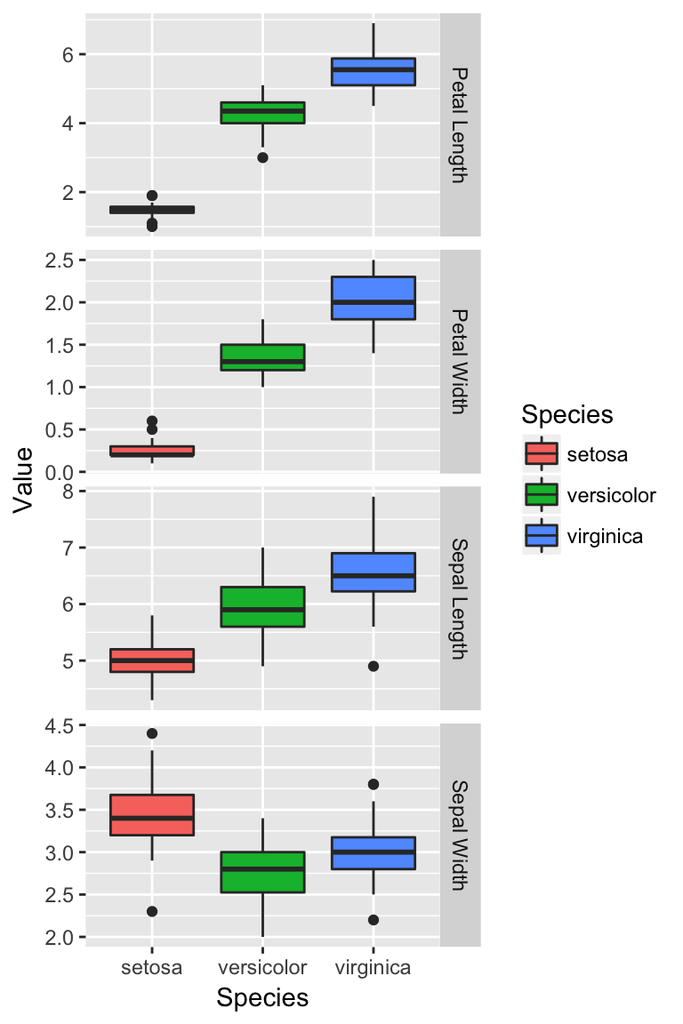

```r
label_map <- c(Petal.Width = "Petal Width",
               Petal.Length = "Petal Length",
               Sepal.Width = "Sepal Width",
               Sepal.Length = "Sepal Length")

iris %>% gather(key, Value, -Species) %>%
  #color = Species would just change the lines aroud boxes -> use fill
  ggplot(aes(x = Species, y = Value, fill = Species)) +
  geom_boxplot() +
  facet_grid(key ~ ., scale = "free_y",
             labeller = labeller(key = label_map))
```

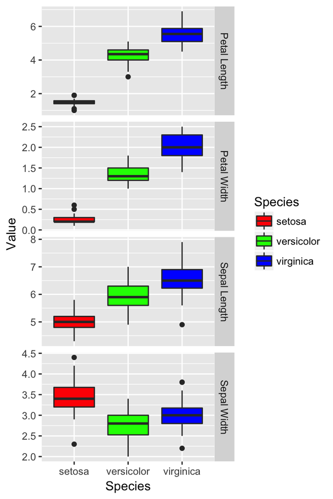

```r
#manual colors
iris %>% gather(Measurement, Value, -Species) %>%
  ggplot(aes(x = Species, y = Value, fill = Species)) +
  geom_boxplot() +
  scale_fill_manual(values = c("red", "green", "blue")) +
  facet_grid(Measurement ~ ., scale = "free_y",
               labeller = labeller(Measurement = label_map))
```

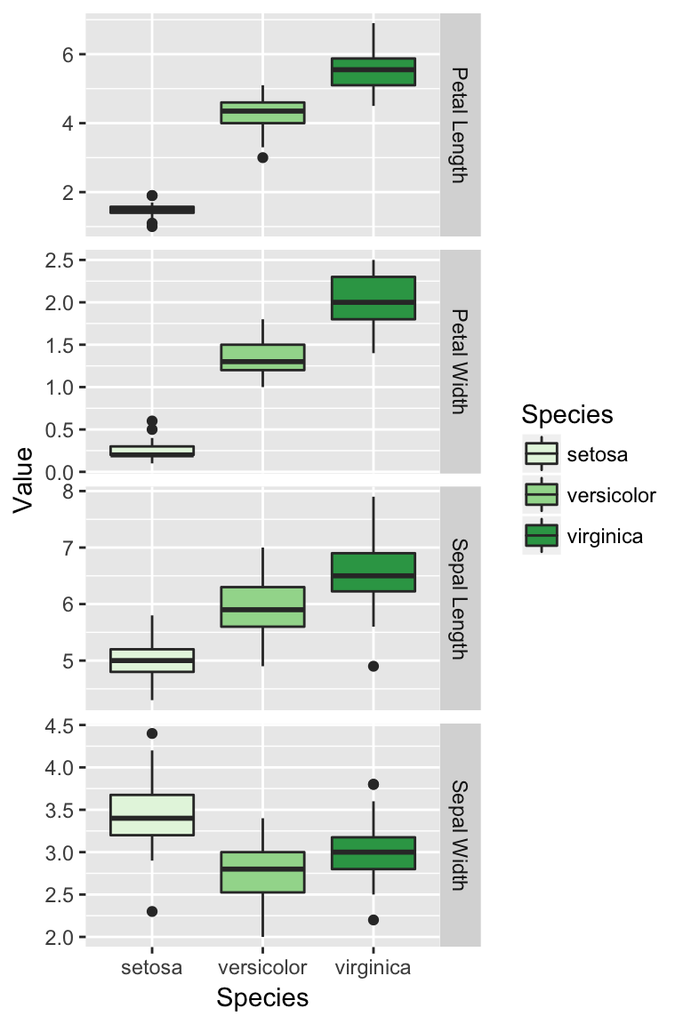

```r
#following option might prevent the colors from being badly seen by color-blind people
iris %>% gather(Measurement, Value, -Species) %>%
  ggplot(aes(x = Species, y = Value, fill = Species)) +
  geom_boxplot() +
  scale_fill_brewer(palette = "Greens") +
  facet_grid(Measurement ~ ., scale = "free_y",
               labeller = labeller(Measurement = label_map))
```

### Changing the plots with theme and other functions

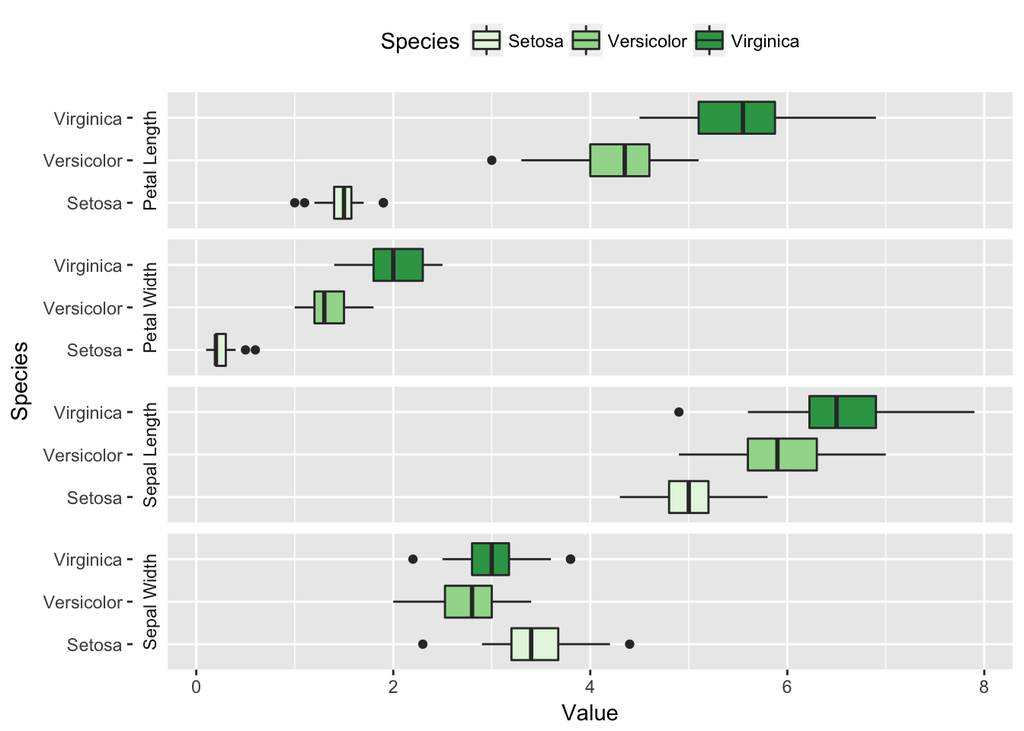

```r
label_map <- c(Petal.Width = "Petal Width",
               Petal.Length = "Petal Length",
               Sepal.Width = "Sepal Width",
               Sepal.Length = "Sepal Length")
#it can be named even with ""
species_map = c("setosa" = "Setosa",
                "versicolor" = "Versicolor",
                "virginica" = "Virginica")

iris %>% gather(Measurement, Value, -Species) %>%
  ggplot(aes(x = Species, y = Value, fill = Species)) +
  geom_boxplot() +
  scale_x_discrete(labels = species_map) +
  scale_fill_brewer(palette = "Greens", labels = species_map) +
  facet_grid(Measurement ~ .,
             switch = "y", #switch the location of measurement labels
             labeller = labeller(Measurement = label_map)) +
  coord_flip() +
  theme(strip.background = element_blank()) + #no background for labels
  theme(legend.position = "top")
```

### Plotting subplots of independent datasets

The ggplot2 package doesn’t directly support combining multiple plots, but it can be achieved using the underlying graphics system, grid

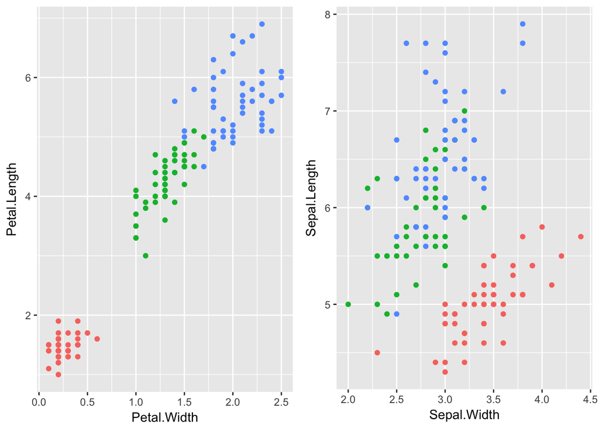

```r
#install.packages("gridExtra")
library(gridExtra)
petal <- iris %>% ggplot() +
  geom_point(aes(x = Petal.Width, y = Petal.Length,
                 color = Species)) +
  theme(legend.position = "none")
sepal <- iris %>% ggplot() +
  geom_point(aes(x = Sepal.Width, y = Sepal.Length,
                 color = Species)) +
  theme(legend.position = "none")
grid.arrange(petal, sepal, ncol=2)
```